# Hake Notes

Andrea Odell

2022-07-04

### June 27 - July 1, 2022

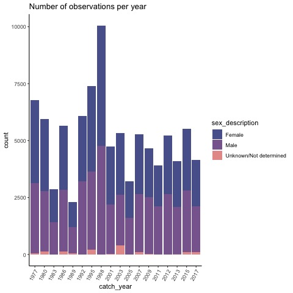

There are 46,816 female observations and 44,982 male observations. There seems to be a fairly equivalent number of males vs females.

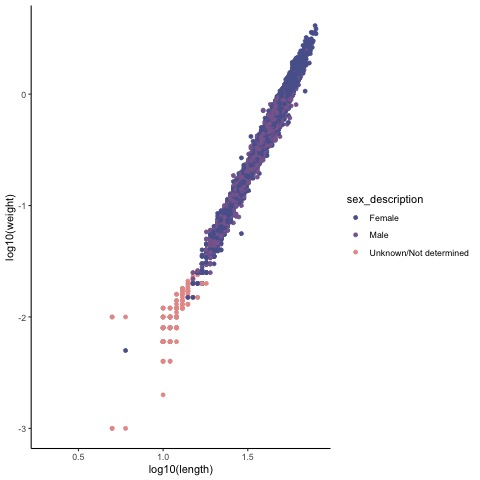

Log10-transformed length weight relationship

Looking more closely at growth, particularly the relationship between length and weight, much of the unknown sex descriptions come from smaller sized fish which makes sense. Females and Males seem to follow very similar growth trends, as indicated by fitting separate growth models to each sex and estimated coefficients being fairly similar. Visually, there seems to be a greater abundance of females at those larger sizes.

Because of the similarity between males and females and because males and females are not modeled explicitly in the stock assessment, I went ahead and continued modeling the sexes aggregated together. I did this by first subsetting `hake_df` to observations that had complete length and weight information `fit_hake_df` - 52,382 observations. I log10-transformed the data (this was recommended over natural log transformation), and fit a linear model using `lm()`, a least squares method. The resulting model then became
$$log_{10}(W) = log_{10}(a) +
b*log_{10}(L)$$
.

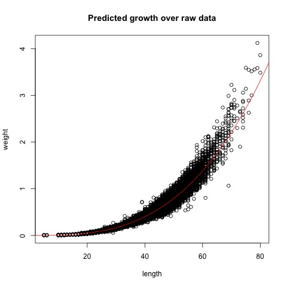

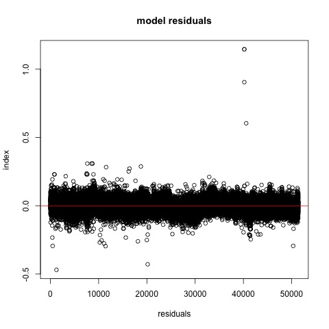

Above is the fitted model over the raw data and a plot of the residuals. The multuple R-squared value of the fit is 0.9819, which means that 98% of the variability can be explained by the model - which is great!

From now, I will be referring to residuals as growth anomalies (… makes more sense in my brain). These next few plots will be exploring patterns in growth anomalies as it relates to time, location, and age.

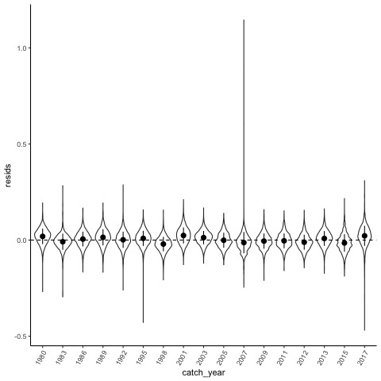

Summary of growth anomalies per year

This first graph shows the variability in growth anomalies per year. Immediately, you notice that 1995, 2007, and 2017 have considerable variability in growth anomalies between individuals (i.e. there is a wide distribution of individuals who are both larger and smaller than normal). The distribution in 2007 is largely driven by 3 outliers, where those outliers are small (length) individuals that are much heavier (weight) than normal. I believe this may be due to measurement error. Years 1995 and 2017 are years adjacent to record warm years (marine heatwaves) which may have led to this variability in growth anomalies due to differential responses between fish (spatial or perhaps age?).

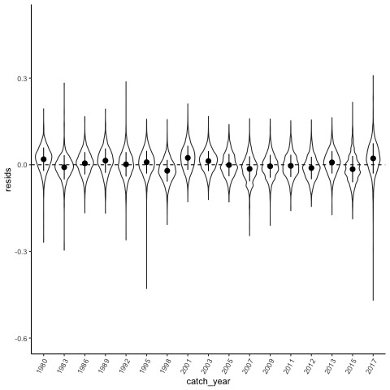

outlier removed

This plot removes the outliers from 2007. You can see that the 3 outliers really drive the distribution - how should we handle these outliers?

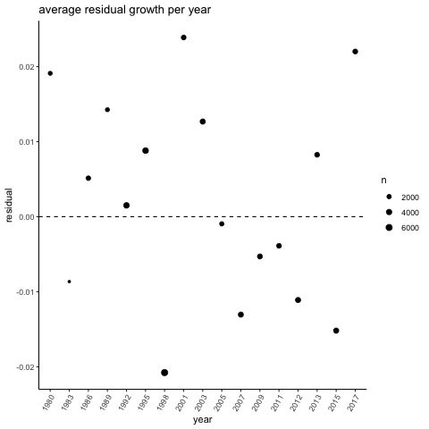

Avg growth anomalies per year

This plot is looking at the average growth anomalies per year without the spread of data. It looks like many of the years prior to 2003 were dominated by larger-than-avg individuals, except the year in which a marine heatwave occured. Following 2003, many of the years are dominated by smaller-than-avg individuals with the exception of 2013 and 2017.

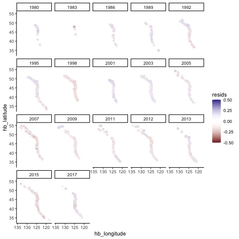

Spatial variation of growth anomalies by year

This graph shows how growth anomalies vary along the west coast every year. Values close to 0 (i.e. observed value is close to predicted - no anomaly) are transparent for better visualization of + and - values. Moreover, those 3 outliers in 2007 are included in the graph, but not in the color scale limit, for improved visualization. You can see there is considerable year-to-year variation, where in 1998 and 2015 you see mostly smaller-than-avg fish all along the coast and aligns with the years with marine heatwaves. In some years, there seems to be a slight stratification, where the northern half of the coast shows larger or smaller-than-avg individuals and southern half vice versa. An issue with this graph is that you can’t see individuals who do not exhibit a growth anomaly, which I think would be valuable to see if this occurs in a part of the coast.

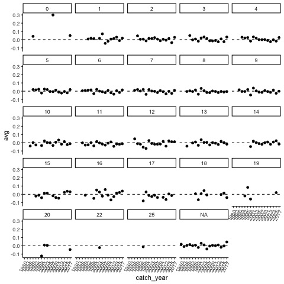

growth anomalies timeseries by age

A time series of average growth anomalies per age group. This essentially reveals how variable growth anomalies are per age - are some ages more vulnerable to variation in growth? are some age classes consistently larger or smaller than average? Either way, this plot is a little hard to decipher.

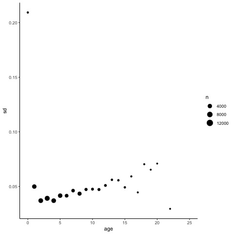

Variability of growth anomaly by age

Summarizing the variability of growth anomalies per age even further, we can see that growth anomalies are most variable at age 0 - likely because there’s fewer data and potentially greater measurement error - and that variability in growth anomalies increases slightly with age. However, there are fewer observations at those older age classes. I plan to create a plus group, by concatenating the age classes 15+ as done similarly in the stock assessment.

### July 4-8, 2022

Some next steps I plan to take this week is I will fit an age at length model to assign ages that don’t have values. I will create a plus group age, grouping all ages 15 and greater. What sort of changes do we see when we make this assumption? I will explore finer temporal resolution to hopefully get an idea of some of the sampling/selectivity bias that might be happening. Another question was whether there was spatial variation in which sex dominates? All of this should then lead to some statistical modeling to determine relative importance of the patterns that I am seeing.

Okay, to start with estimating age using an length-at-age model, I first subsetted the `hake_df` dataframe so that there is only complete cases for age and length columns named `age_hake_df`. Then I added a new column `new_age` which were ages including plus group (ages 15+)

I first fit a Von Bertalanffy model to the whole data (all years combined), then fit a Von Bertalanffy model assuming “two regimes” where I fit the model to years 1980-2003 and 2004-2017, and finally I fit a Von Bertalanffy model to the plus group data. $size \sim L_{\infty}/(1 + exp(-K * (age - t_0)))$

I selected the regimes by visually determining years with the most similar average growth anomalies (1980-2003 had larger-than-avg individuals and 2004-2017 had smaller-than-avg).

There was negligible differences in fit and coefficients between the whole data scenario (RSS = 551852) and the plus group scenario (RSS = 551912). However, when the data was split into regimes the fit of the model improved as indicated by the Residual Sum Squares (RSS = 324002/200280).

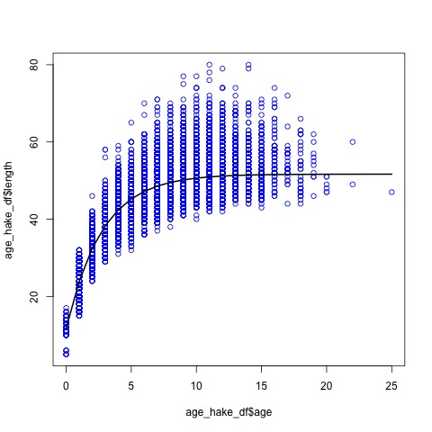

Growth curve to whole data

Because I created a plus group, I wanted to go back and look at some of the data visualizations I did last week to see if there were any big changes.

First, I looked at the variability in growth anomalies per age by plotting the residual standard deviation for each age. The size and color of the points indicate number of observations and whether the residuals are positive on average (i.e. larger-than average), respectively.

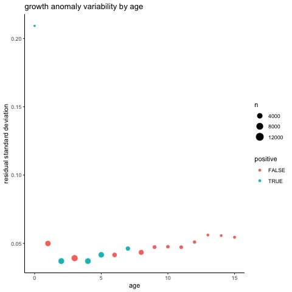

When estimating ages, it’s worth making sure I understand what ages we are estimating. Below is a rough length frequency plot by age, where colors indicate age, and the grey line indicates observations that haven’t been assigned an age. A lot of the observations with unassigned ages are larger individuals, and the VB models I have explored so far underestimate the ages of those larger indivudals. How should I proceed?

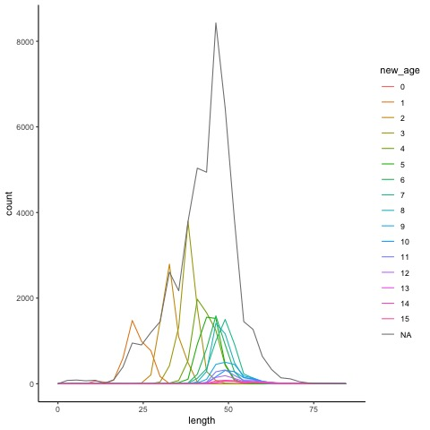

Looks like age 6+ are fairly similar lengths - increased potential for mis-assigning these ages?

In terms of the stock assessment, the 2006 assessment modeled growth 3 ways: time-varying K, density dependent growth, and cohort-specific K.

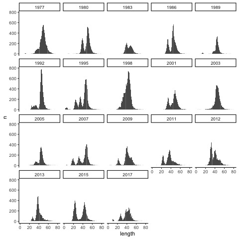

Length frequencies by year

Notes from meeting with Kristin 7/7/22

- The weight/age/year data may not be considered confidential and could request to get that data.
- Interesting to look at spatial and temporal variation (check Maia Kapur’s work).
- Potential big-picture questions
  - How can we leverage this information of growth anomalies? Are there cohort effects? Is there an effect on future spawning?
  - Are there bigger recruitment events in years with fatter fish?
  - Do fish that are fatter in the early lie stages, stay fatter throughout their life?
  - Ultimately, how can we develop a model that goes into the MSE?
- Next steps:
  - Still have to explore finer temporal resolution
  - hierarchical or mixed growth model with time varying K

### July 11-15, 2022

How do weight-length anomalies vary through time for a specific age?

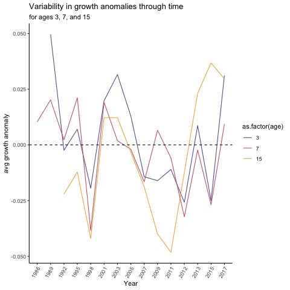

It looks like fish condition for a younger ages vary much more stochastically compared to the plus group age that has much more low-frequency fluctuations. Potentially because they aren’t growing quite as much at this age? Or lag effect with younger ages moving into this plus group?

And similarly, looking at how cohort condition varies through time

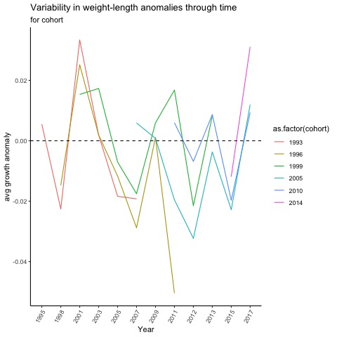

Doesn’t look like there aren’t too many patterns between cohorts.

- **Meeting with Kelli Johnson (7/14/22) on weight at age**
  - weighting process
    - summarizes the data and then use that to weight things
    - assumes all fish of the same age have the same weight
    - only use individuals with ages when working with age composition and weight at age
    - use individuals with length, weight, and age to groundtruth if needed
  - data_wtatage()
    - needs maturity ogive and catches to get mean weight at age. uses previous years to fill in missing age information
    - assumes every population process going through SS uses the same weight at age (between different data sources - fishery vs survey vs etc)
    - sampling date as potential covariates (do we need to take into account sampling month when we do weighting?)
    - could model season (season just means month) but the caveat is that we need to fill in everything, and so that’s just more estimating ages
    - if the estimated ages look the same regardless if we add biological realism then who cares
    - female only modeled
    - ignoring this dilutes the potential that surveys/data sources are sampling different fish
    - may need some way to fill in missing information better based on the results that we (kristin and i) find
      - what if there’s a regime shift but we don’t account for that
      - are there environmental covariates that may drive changes in weight at age?
    - SS there’s flexibility in how you want to fill in these values
    - factors influencing weight at age
      - sampling bias
      - cohort effects
      - environmental effects
    - check how Pollock assessment fills in missing information
    - Sablefish also has a lot of data to test on
    - visualize weight at age over the raw data to see if there are strong cohorts coming through
    - Line 157 in github code - beginning of where they fill in missing values
- **Meeting with Kristin**
  - random effects
    - year
    - cohort
    - to establish cohort, we can create a cohort ID that is their birth year (cohort ID = current year - age) - We could also look at how growth anomalies relate to the size of the population or cohort to get into some density dependence effects
  - 3 potential ways to model weight at age
    - random effect just on age
    - gam (does brms have gams)
    - boosted regression trees
      - Doesn’t give insight into mechanism, so might be difficult to translate into something for MSE
  - For the growth anomaly variability line graph, we could also look at
    - ages 1 and 2
    - immature vs mature fish
    - To think about: age 3 fish have fairly variable growth anomalies and they are also the biggest contributor to recruitment
      - how does this variability affect population dynamics
  - Note: big cohorts happened in 1999 and 2010

I tested out different GAMs using `gam()`, as well as running it in `brms`.

1. Simple GAM with no random effects

```r
gam_out <- gam(weight ~ s(new_age), data = hake_weight_age_df, method = "REML")
```

2. GAM with group-level smoothers with different wiggliness for year

```r
gamm_out = gam(weight ~ s(new_age, bs="tp") +
      s(new_age, by = catch_year, m = 1, bs="tp") +
      s(catch_year, bs="re"),
      data = hake_weight_age_df, method="REML")
```

3. GAM with group-level smoothers with same wiggliness for year

```r
gamm_GS_out = gam(weight ~ s(new_age, m = 2) +
                 s(new_age, catch_year, bs="fs", m = 2),
               data = hake_weight_age_df, method="REML")
```

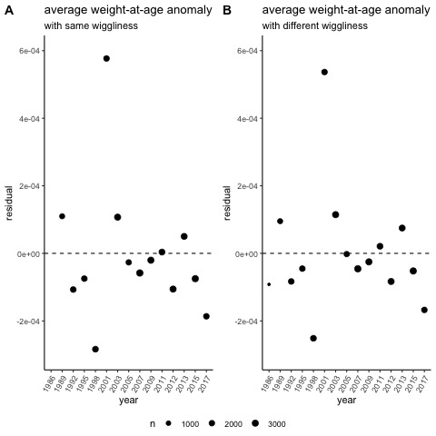

4. GAM with group-level smoothers with different wiggliness for cohort

```r
gamm_cohort_out = gam(weight ~ s(new_age, bs="tp") +
                        s(new_age, by = cohort, m = 1, bs="tp") +
                        s(cohort, bs="re"),
                      data = hake_weight_age_df, method="REML")
```

5. GAM with group-level smoothers with same wiggliness for cohort

```r
gamm_GS_cohort_out = gam(weight ~ s(new_age, m = 2) +
                    s(new_age, cohort, bs="fs", m = 2),
                  data = hake_weight_age_df, method="REML")
```

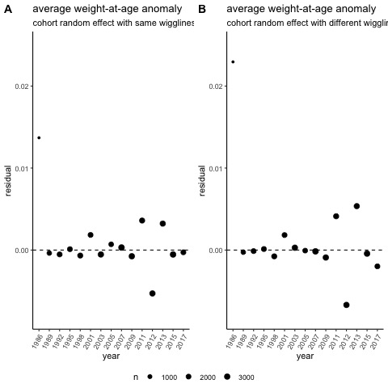

### July 18-22, 2022

Of all 5 models, `gamm_GS_cohort_out` had the smallest AIC value.

- Notes on weight-length and weight-at-age and how they may relate
  - weight-length relationships are indicative of “body condition”
  - weight-at-age is a rate, so potentially indicative of growth rate
6. GAM with group-level smoothers with same wiggliness for cohort and year

```r
gamm_GS_year_cohort_out = gam(weight ~ s(new_age, m = 2) +
                           s(new_age, cohort, bs="fs", m = 2) +
                           s(new_age, catch_year, bs="fs", m = 2) ,
                         data = hake_weight_age_df, method="REML")
```

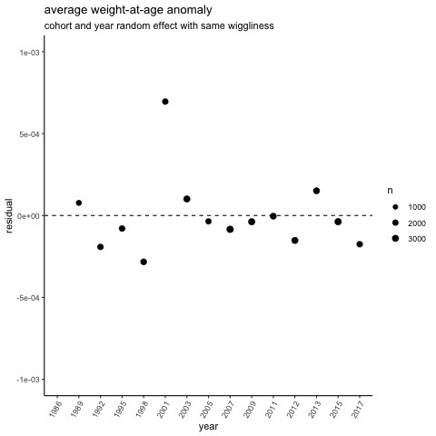

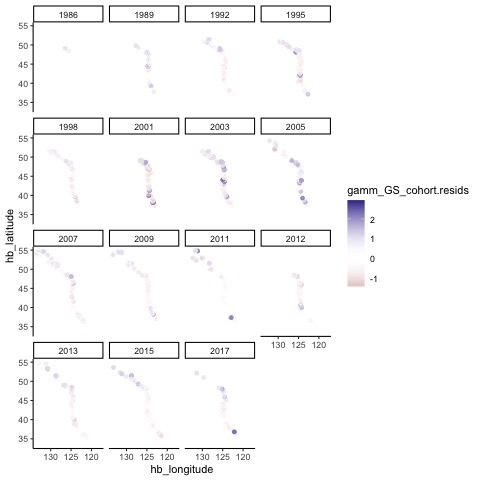

Looking at how weight-at-age anomalies vary spatially by year, there seems to be a lot more within year, spatial variation compared to between years. This is in stark contrast from visualising the length-weight relationship. This plot only shows for the gam model with cohort RE and same wiggliness (model 5). However, there were no visual differences between the other models that I tried (model 3 and 6).

Okay, I need a recap:

- weight-length relationship
  - greater year-to-year spatial variation
  - plus group has lower freq variability through time vs younger ages are much more stochastic
  - No clear pattern between cohorts when looking at weight-length variability through time
- weight-at-age
  - greater within-year spatial variation
  - Different temporal trends in average growth anomaly depending on model used

Meeting with Kristin

- gams
  - don’t put smoothers on random effect
- year-to-year effects are better explained because the residuals are smaller
- write down hypothesis about how weight-at-age should vary with cohorts or years
  - different curve for each cohort
- LOOIC instead of AIC (look at Michael Malick papers 2020)
- Think about what I want to get out of the internship and make sure we’re accomplishing that

### July 25-29, 2022

**Potential questions of interest**  
- Explore spatio-temporal patterns in growth of Pacific Hake  
- Identify potential covariates of growth trends and develop an environmental index  
- Quantify the performance of incorporating an environmental index on growth  
- Separately, test importance/sensitivity of SS of filling in missing weight-at-age information assuming average vs environmentally driven weight-at-age  
- Incorporate into the MSE?

**Goals for the rest of the summer**  
- Solidify motivation and guiding questions  
- Identify promising methods/approaches  
- Begin writing

This week I did more work on the gam modeling and now have a better grasp on what I am modeling. Last week, the models I was fitting were gam models with “random wiggliness” where each cohort and year had their own wiggliness/spline action. However, we are more interested in random effects where there is just a shift in the position of the curve (intercept?), but the shape remains the same. With that in mind, I realized we could still use the smoothing function (because smoothing process also involves shrinkage and has a direct link to the shrinkage involved in random effects) and specify `bs = 're'`.

I just tested a Bayesian GAMM with year and year+cohort random effects.

1. Bayesian GAMM with only year RE

```r
gamm_year_brm_out = brm(bf(weight ~ s(new_age) + s(catch_year, bs="re")),
                    data = hake_weight_age_df, family = gaussian(), cores = 4,
                    iter = 2000, warmup = 1000, chains = 4)
```

2. Bayesian GAMM with year and cohort RE

```r
gamm_year_cohort_out = brm(bf(weight ~ s(new_age) + s(catch_year, bs="re")
                              + s(cohort, bs="re")), data = hake_weight_age_df, family = gaussian(),
                           cores = 4, iter = 2000, warmup = 1000, chains = 4)
```

Model comparisons: elpd_diff se_diff gamm_year_cohort_out 0.0 0.0 gamm_year_brm_out -1632.4 110.9

Because the model with year + cohort RE was a better fit to the data, I continue on only looking at that model

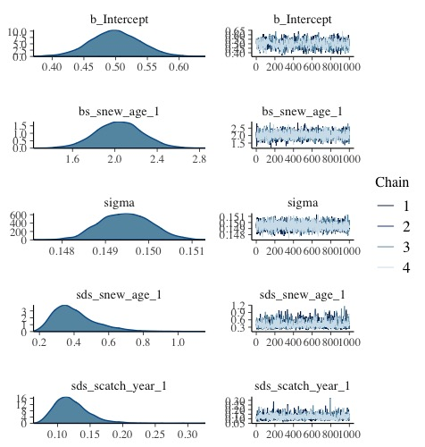

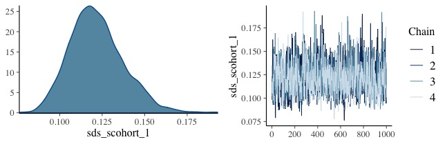

Density and traceplots look good - got the hairy caterpillars

Either way, the next few plots will be summaries of the coefficients.

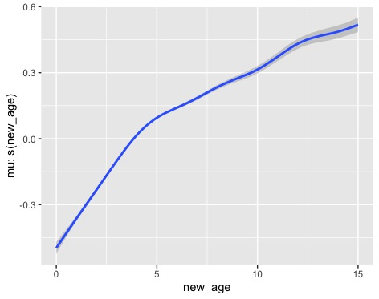

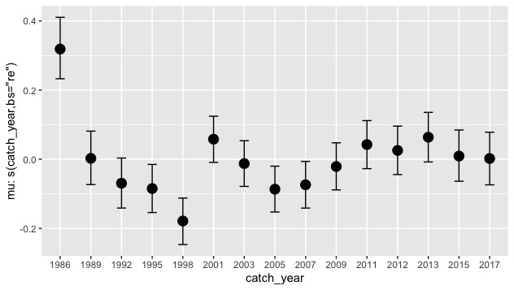

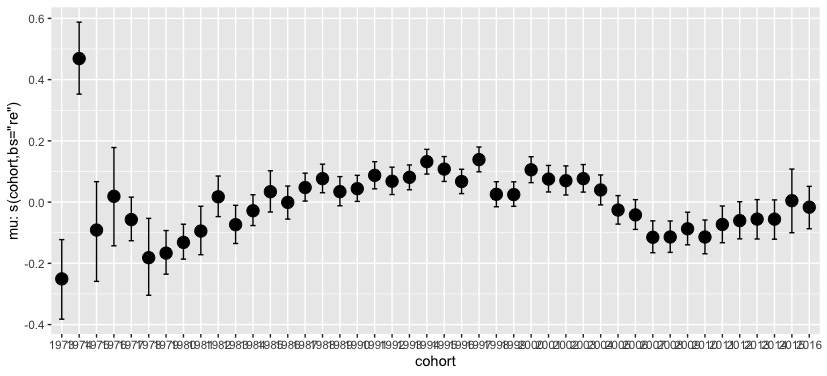

I am still trying to figure out how to graph these myself so that I can customize the graphs, but for now these will do..

Very clear year and cohort effects, some with credible intervals not passing over 0. Does that mean something like how it means in confidence intervals?

**Questions**

- How to best explore “year” and “cohort” effects - is just specifying random effects okay?
  - are these effects important and how important are they relative to each other?
    - have a model for each (no RE, just cohort, just year, both)
    - look at sd for year vs cohort. which has more variability
- where can I get recruitment and biomass information?

**Questions for presentation in hake meeting**

- potential environmental covariates to explore linked to growth? What is available?
- spatio-temporal methods?
  - sdm-TMB
  - gam with smoothers on lat,long
- thoughts on length-weight vs weight at age?
- Other assessments that use environmental indicators/indices that I can gain inspiration from?
- proposed research questions

**Meeting with Kristin** ]

- what makes weight at age different from recruitment? there is no real way to put an environmental driver into stock assessment since it is empirical
  - rather, explore how incorporating an environmental driver affects the matrix of weight at age that does go into the assessment
  - MSE: historical period using same empirical weight at age as estimation model, future assumes average weight at age (not a good assumption)
- Fix assumed distribution in brms (lognormal/gamma)
- does spatial matter? If not, then we can lump data together with fishery data and get a longer time series
  - dig into smaller time-scale
- Next steps
  - model comparison
    - add smoother on lat,long (start simple model with just weight at age no RE)
  - identifying potential covariates
    - temperature, upwelling, decadal?
- recruitment and biomass information
  - pacific hake mse github - assessment repository
  - include as a potential driver

### Aug 1-5, 2022

**Notes from presentation**

- Kelli: cohort effect of ageing error
  - strong cohorts have more ageing error
    - can lead to unequal smoothing
    - smoother would be smoothing out ageing error?
    - in stock synthesis, treat strong cohorts differently
  - maybe add a cohort efect for large cohorts
  - Kiva doesn’t think it’s that important (error in variables)
  - Even if I don’t include it in the model immediately, it could be a way to explain some of the results
- For gamm with year and cohort random effect, there was agreement on the presence of autocorrelation in the cohort random effect
  - perhaps above average weight at age carrying through
- In terms of temporal trends, previous surveys were a different temporal window. If we could show that there are no differences in short timescale, then that’s also good to know
- sdm-TMB - run all the models with and without spatial effects - get started on this (after looking into modes - next point)
- Figure out what those modes are in the observed weight data (pp_check) - are they ages 1,2, and 3?
- Motivations for population dynamics fellowship
  - Lay the groundwork for what we might build into a forecast (so instead of interpolating, we can extrapolate)
  - They want to include an internally estimate weight at age into FIMS, and so this work can directly inform how they do that

Fixed the distribution from gaussian to lognormal and re-ran the 4 models in brms. 1. Just age as a predictor  
2. age with catch_year random effect  
3. age with cohort random effect  
4. age with both catch_year and cohort random effect

The posterior predictive check is much better when using the lognormal distribution, but there seems to be some bias in predictions as shown by the offset peaks.

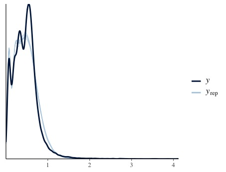

So, what are those peaks? Through some simple visualisation, it looks like the peaks are associated with ages as opposed to cohorts. The first peak is the age 1 individuals, the second peak is ages 2 and 3, and the third peak is a compilation of the rest of the ages.

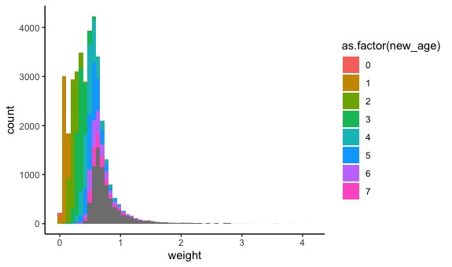

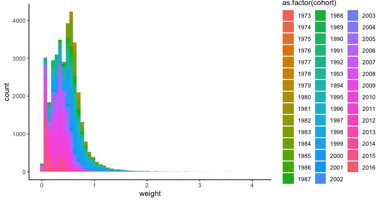

Now I am on a quest to minimize the bias!

I am instead running more gams in mgcv since that has been much faster. In terms of the bias in the posterior predictive check, I originally thought a gamma distribution might be a better fit than the lognormal, but that doesn’t seem to be the case when I looked at the outputs and GCV which is a leave one out cross-validation that acts similarly to the AIC. So, I continue to use a lognormal (or at least in the gam case, I am using a gaussian with log link - which hopefully is fine… couldn’t find the lognormal distribution option in mgcv)

I also included a smoother on latitude to hopefully capture some of the residuals in the larger fish. Below is a plot of the partial effects for the gam with catch_year random effects, s(cohort), and s(latitude) and you can see the new_age is still underpredicting for those older ages

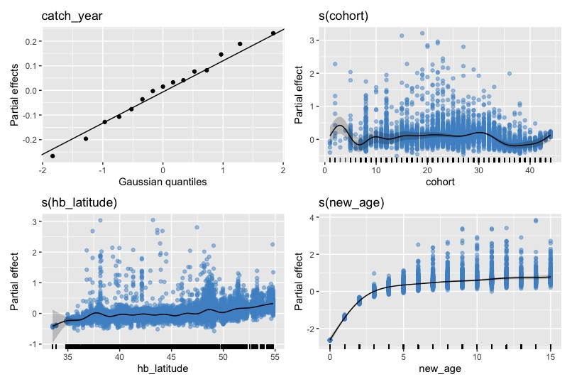

I also learned about new diagnostic checks using `gam.check` to determine if the number of knots is too low (predictors with k > 1 or a significant p-value)

### Aug 8-13, 2022

Following the gams fit last week and the significance of at least a smoother on latitude, I am making the switch to sdm-TMB and going to start figuring out how to use it.

- check correlation structure

Notes on coordinate system for sdmTMB

- have to convert from LatLong to UTM which minimizes distortion and has attributes that make estimating distances easy and more accurate.
- Pacific Northwest is UTM zone 10 (EPSG: 32610)

**I was on vacation from Thursday - Monday**